# Determining the Utility of TMPRSS2-ERG Fusion Status for Prediction of Disease Aggressiveness

## Linear Model 1

- Uses TMRPSS2-ERG fusion status (binary variable) and Age (continuous variable) to predict aggressiveness of disease

```r
## Simple LINEAR MODEL
## Use mutation to test aggress score. Uses  age as control

Simple_OLS <- lm(Aggressiveness_Score ~ TMPRSS2.Simplified + Age, Clinical_Train)
summary(Simple_OLS)
```

```
Call:
lm(formula = Aggressiveness_Score ~ TMPRSS2.Simplified + Age,
    data = Clinical_Train)

Residuals:
     Min       1Q   Median       3Q      Max
-3.06088 -0.85410 -0.05717  0.69037  2.72799

Coefficients:
                           Estimate Std. Error t value Pr(>|t|)
(Intercept)                -3.72797    1.11175  -3.353 0.001189 **
TMPRSS2.SimplifiedPositive -0.08069    0.24882  -0.324 0.746508
Age                         0.06028    0.01742   3.459 0.000845 ***
---
Signif. codes:  0 '***' 0.001 '**' 0.01 '*' 0.05 '.' 0.1 ' ' 1

Residual standard error: 1.171 on 86 degrees of freedom
Multiple R-squared:  0.1247,    Adjusted R-squared:  0.1043
F-statistic: 6.124 on 2 and 86 DF,  p-value: 0.003261
```

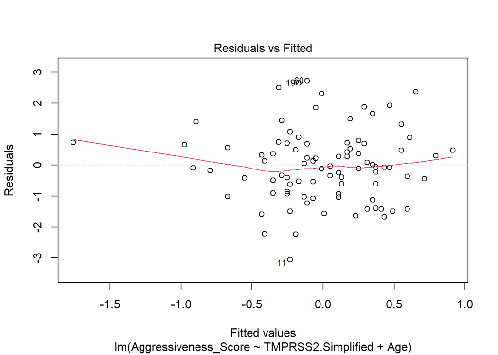

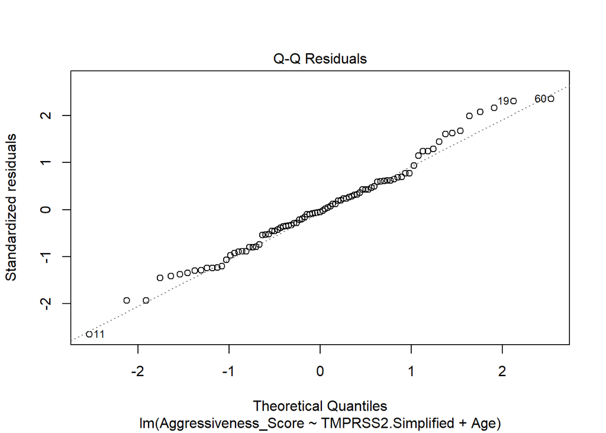

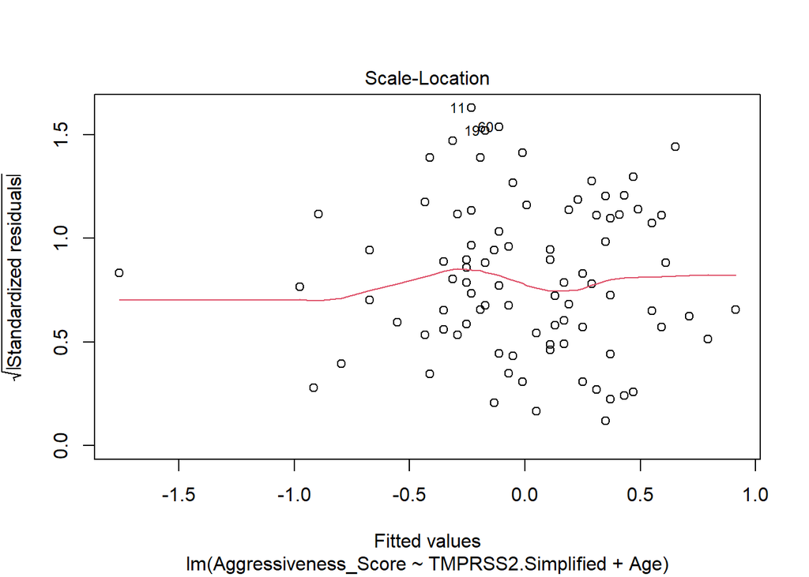

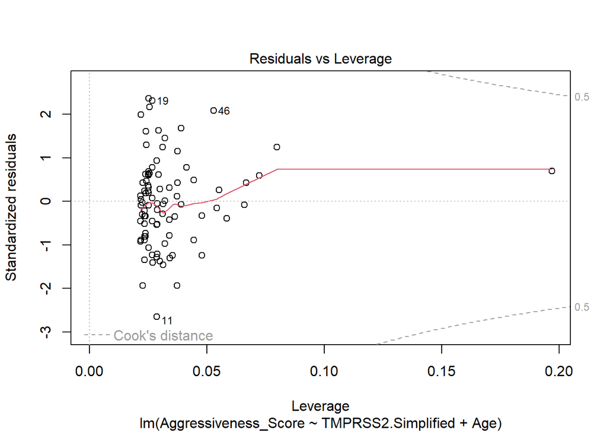

```r
plot(Simple_OLS)
```

## Linear Model 2

- Uses TMRPSS2-ERG fusion status (binary variable) and Age (continuous variable) to predict aggressiveness of disease
- Introduced “*” to the formula to gauge interaction between variables.

```r
## Simple LINEAR REGRESSION MODEL + INTERACTION BTWEN TMPRSS and AGE

Simple_OLS_Interaction <- lm(Aggressiveness_Score ~ TMPRSS2.Simplified * Age, Clinical_Train)
summary(Simple_OLS_Interaction) ## Showing that neither Age nor Mutation status are statistically significant predictors of aggressivness score when using OLS model
```

```
Call:
lm(formula = Aggressiveness_Score ~ TMPRSS2.Simplified * Age,
    data = Clinical_Train)

Residuals:
     Min       1Q   Median       3Q      Max
-3.07662 -0.84848 -0.04129  0.69053  2.71858

Coefficients:
                                Estimate Std. Error t value Pr(>|t|)
(Intercept)                    -3.528830   1.843005  -1.915   0.0589 .
TMPRSS2.SimplifiedPositive     -0.391310   2.298917  -0.170   0.8652
Age                             0.057115   0.029126   1.961   0.0532 .
TMPRSS2.SimplifiedPositive:Age  0.004956   0.036465   0.136   0.8922
---
Signif. codes:  0 '***' 0.001 '**' 0.01 '*' 0.05 '.' 0.1 ' ' 1

Residual standard error: 1.178 on 85 degrees of freedom
Multiple R-squared:  0.1249,    Adjusted R-squared:  0.09397
F-statistic: 4.042 on 3 and 85 DF,  p-value: 0.009739
```

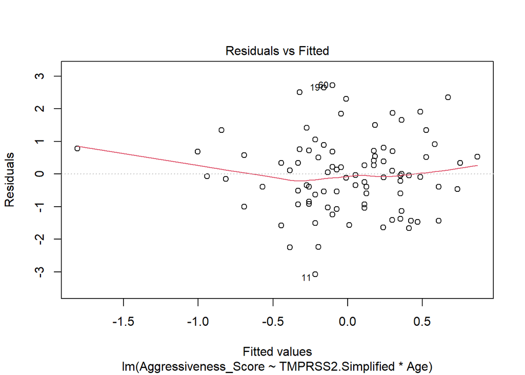

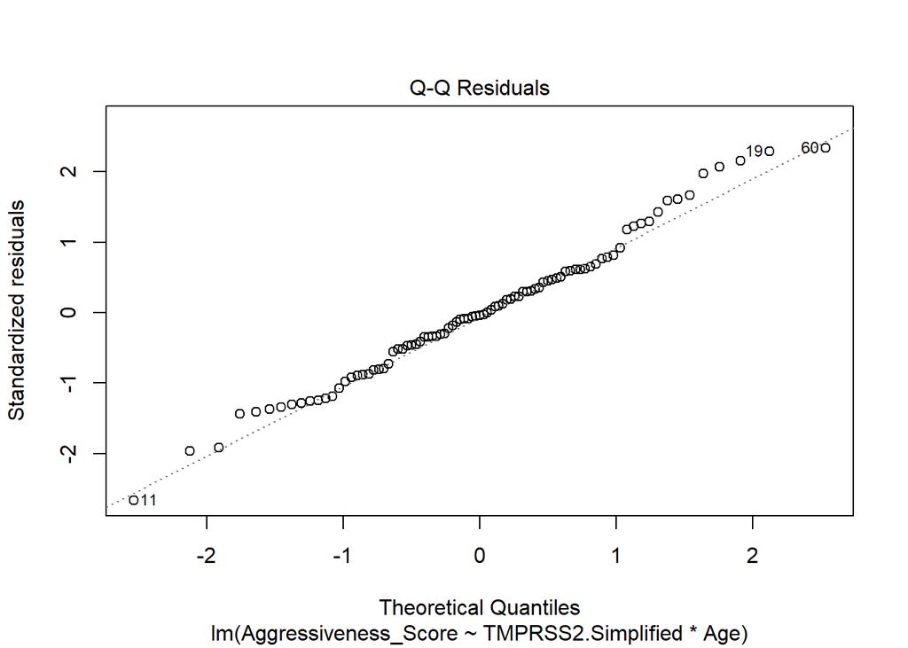

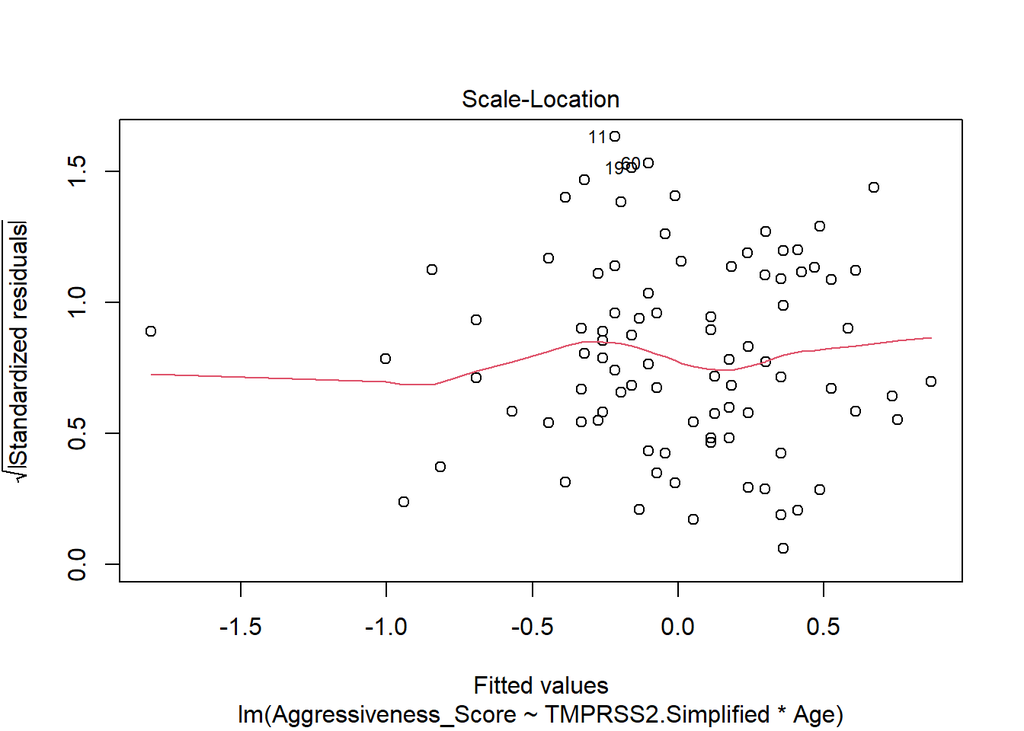

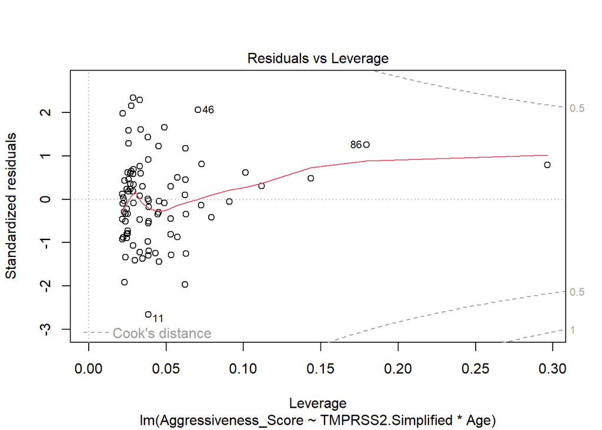

```r
plot(Simple_OLS_Interaction)
```

## Linear Model 3

- Uses TMRPSS2-ERG fusion status (binary variable) and Age (continuous variable) and Mutation Count (continuous) to predict aggressiveness of disease (Added another variable - Mutation Count)

```r
## Complex LINEAR REGRESSION MODEL - evaluates age and mutation account (two variables)
Complex_OLS_Interaction <- lm(Aggressiveness_Score ~ TMPRSS2.Simplified + Age + Mutation.Count, Clinical_Train)
summary(Complex_OLS_Interaction)
```

```
Call:
lm(formula = Aggressiveness_Score ~ TMPRSS2.Simplified + Age +
    Mutation.Count, data = Clinical_Train)

Residuals:
    Min      1Q  Median      3Q     Max
-2.1134 -0.4271 -0.1047  0.4572  1.7586

Coefficients:
                            Estimate Std. Error t value Pr(>|t|)
(Intercept)                -3.102536   0.710998  -4.364 3.58e-05 ***
TMPRSS2.SimplifiedPositive -0.395901   0.161095  -2.458    0.016 *
Age                         0.013730   0.011855   1.158    0.250
Mutation.Count              0.075117   0.006677  11.250  < 2e-16 ***
---
Signif. codes:  0 '***' 0.001 '**' 0.01 '*' 0.05 '.' 0.1 ' ' 1

Residual standard error: 0.7466 on 85 degrees of freedom
Multiple R-squared:  0.6483,    Adjusted R-squared:  0.6359
F-statistic: 52.23 on 3 and 85 DF,  p-value: < 2.2e-16
```

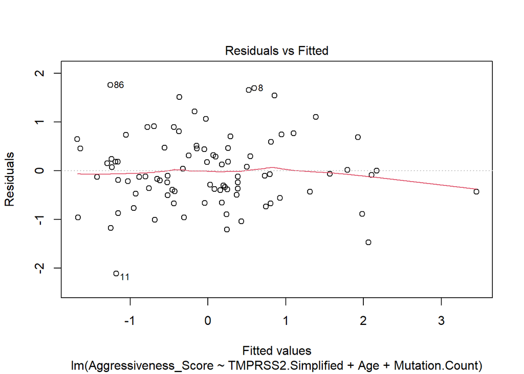

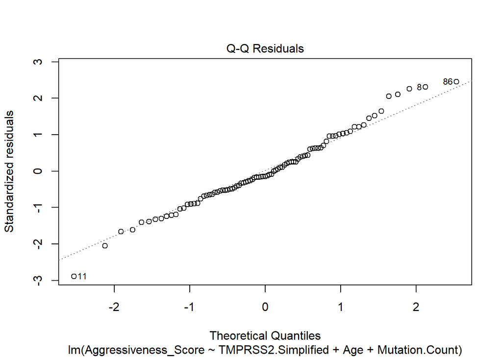

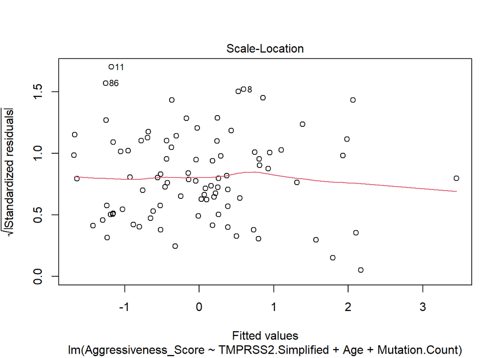

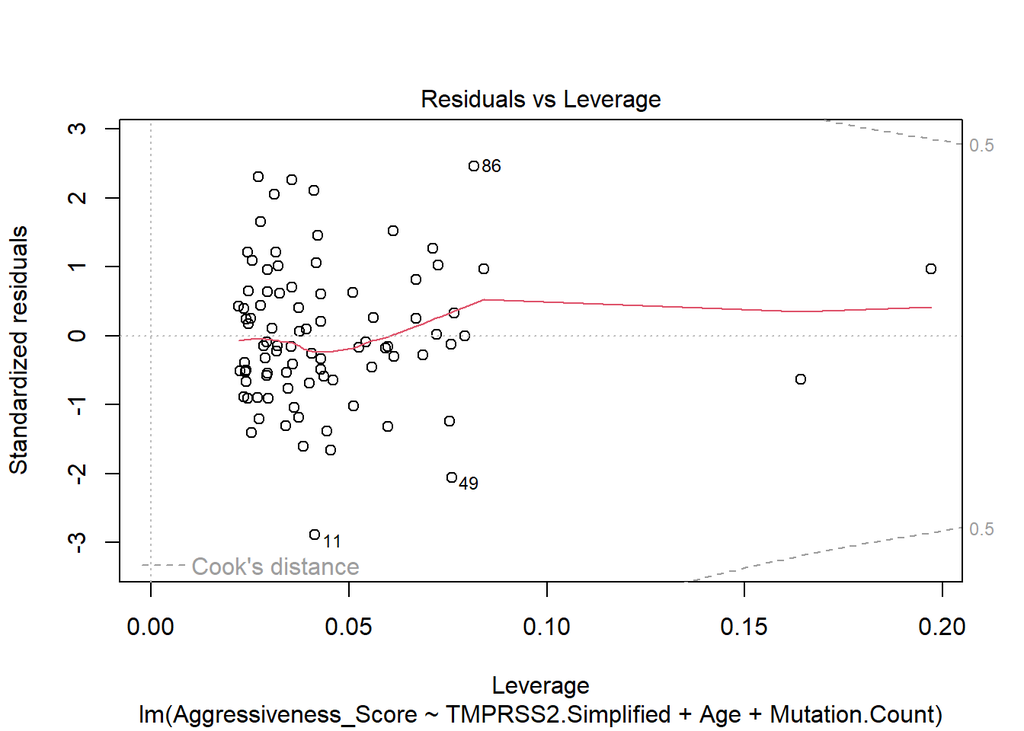

```r
plot(Complex_OLS_Interaction)
```

## Linear Model 4

- Uses TMRPSS2-ERG fusion status (binary variable) * Age (continuous variable) and Mutation Count (continuous) to predict aggressiveness of disease
  - Added another variable - Mutation Count and introduced “*” to the formula to gauge interaction between variables

```r
## Complex LINEAR REGRESSION MODEL + INTERACTION BTWEN TMPRSS and AGE
Complex_OLS_Interaction <- lm(Aggressiveness_Score ~ TMPRSS2.Simplified * Age + Mutation.Count, Clinical_Train)
summary(Complex_OLS_Interaction)
```

```
Call:
lm(formula = Aggressiveness_Score ~ TMPRSS2.Simplified * Age +
    Mutation.Count, data = Clinical_Train)

Residuals:
    Min      1Q  Median      3Q     Max
-2.1170 -0.4286 -0.1028  0.4584  1.7473

Coefficients:
                                Estimate Std. Error t value Pr(>|t|)
(Intercept)                    -3.058001   1.175996  -2.600    0.011 *
TMPRSS2.SimplifiedPositive     -0.465409   1.465982  -0.317    0.752
Age                             0.013026   0.018987   0.686    0.495
Mutation.Count                  0.075112   0.006717  11.182   <2e-16 ***
TMPRSS2.SimplifiedPositive:Age  0.001109   0.023255   0.048    0.962
---
Signif. codes:  0 '***' 0.001 '**' 0.01 '*' 0.05 '.' 0.1 ' ' 1

Residual standard error: 0.751 on 84 degrees of freedom
Multiple R-squared:  0.6483,    Adjusted R-squared:  0.6316
F-statistic: 38.71 on 4 and 84 DF,  p-value: < 2.2e-16
```

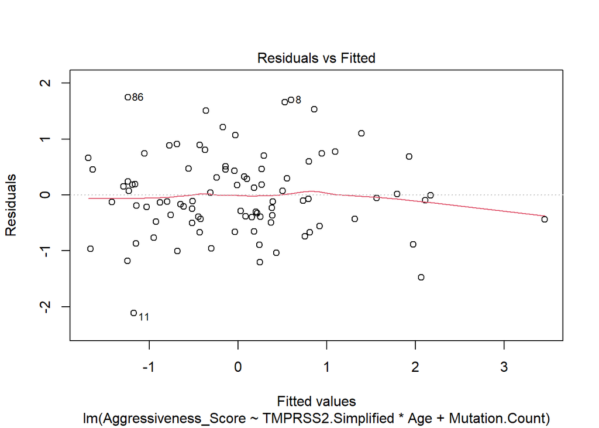

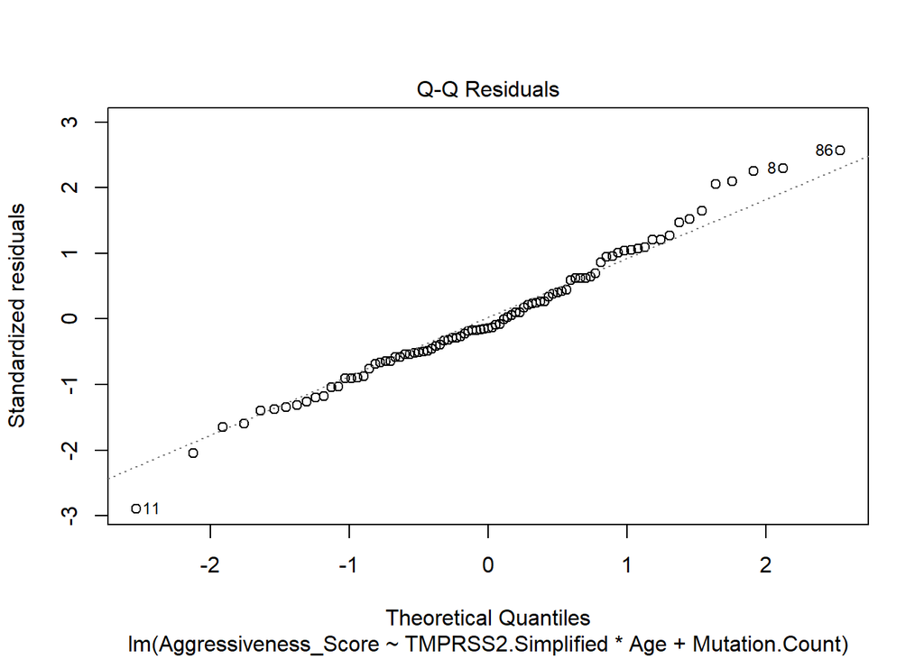

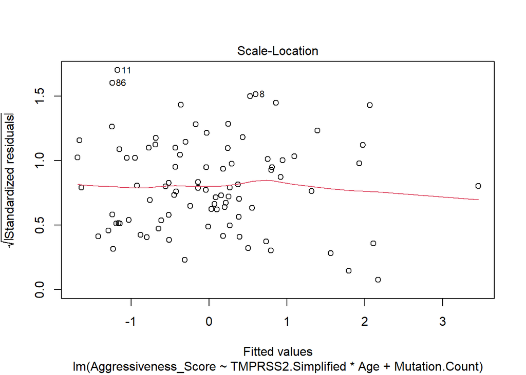

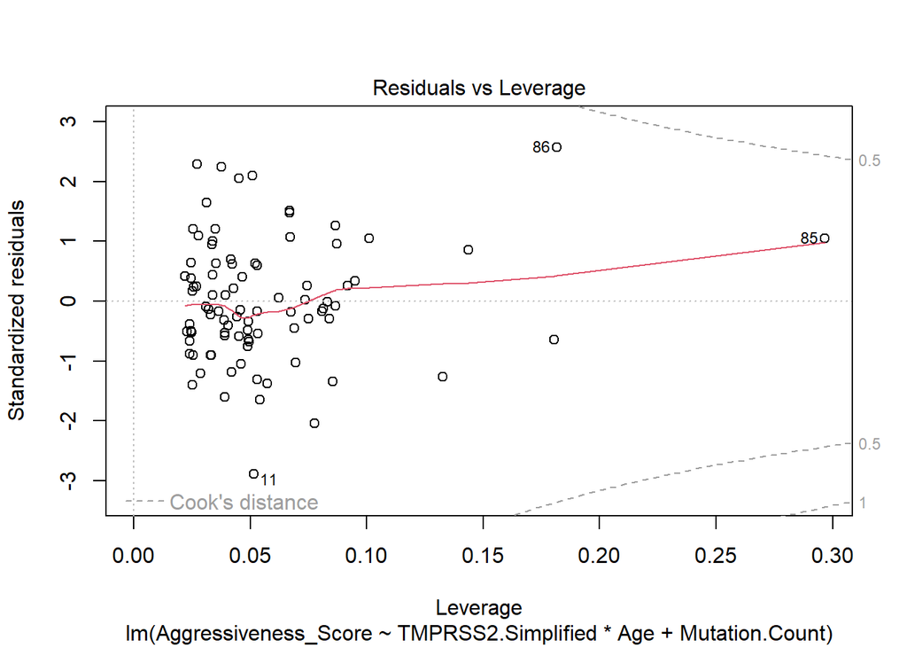

```r
plot(Complex_OLS_Interaction)
```